# Ontario Private and Public School Enrolment

[figure not shown]

The purpose of this repository is to provide a single point of access for data on private and public school enrollment in Ontario. It contains:

1. the original datasets reporting [private](https://data.ontario.ca/dataset/private-school-enrolment-by-gender) school and [public](https://data.ontario.ca/dataset/school-enrolment-by-gender) school enrollment from the Ontario Open Data database.
2. An R Script that loads each file and performs extremely basic data cleaning tasks.
- It converts all variable names to title cases
- Sets cells with values “<10”” to have a value of 5
- deletes values with “SP” because these are not defined in the data documentation
- filters out rows in the public school data-set that are totals
- Recalculates new enrolments for the private schools from the total male and female enrolments
- binds the two data sets together into one and saves that file out.
3. A combined dataset that shows public and private school enrollment in Ontario.

To cite, please see the citation file to the right.

The basic graph of interest is here:

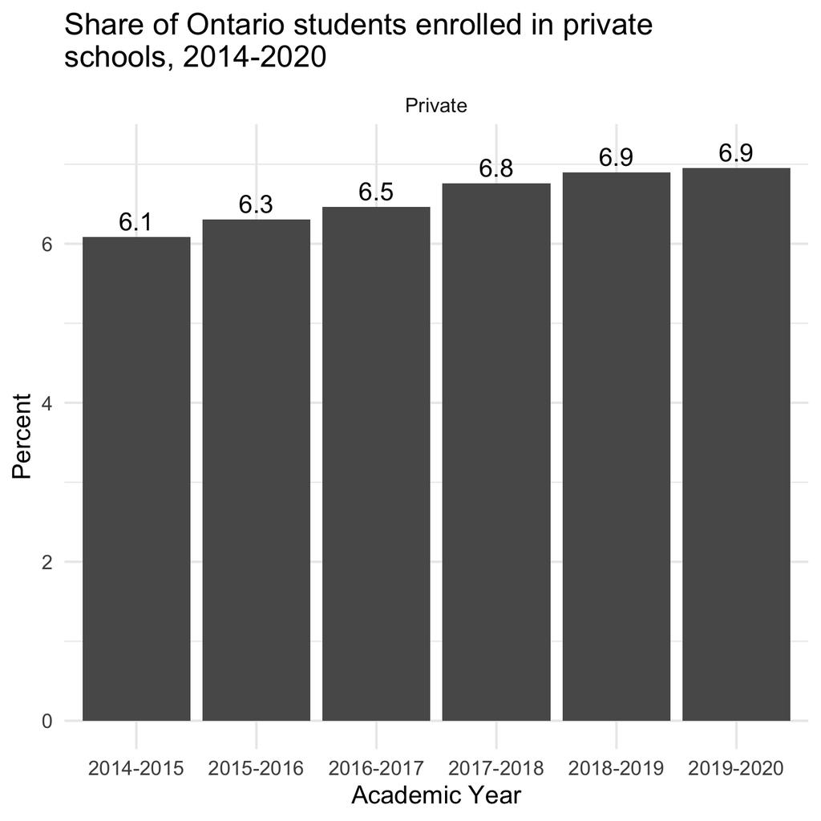

I’ll commit to updating this repository as data becomes available. If anyone spots any concerns, please contact me or open a pull request.